# Single Cell RNAseq Part 6

Bioinformatics Core

# Part 6: Enrichment, Model-Based DE, and Cell-Type Identification

## Load libraries

```r
library(Seurat)
library(ggplot2)
library(limma)
library(topGO)
```

## Load the Seurat object

```r
load("clusters_seurat_object.RData")
experiment.merged
```

```
## An object of class Seurat
## 21005 features across 10595 samples within 1 assay
## Active assay: RNA (21005 features, 5986 variable features)
##  3 dimensional reductions calculated: pca, tsne, umap
```

```r
Idents(experiment.merged) <- "finalcluster"
```

# 1. Gene Ontology (GO) Enrichment of Genes Expressed in a Cluster

[Gene Ontology](http://geneontology.org/docs/ontology-documentation/) provides a controlled vocabulary for describing gene products. Here we use enrichment analysis to identify GO terms that are overrepresented among the gene expressed in cells in a given cluster.

```r
cluster12 <- subset(experiment.merged, idents = '12')
expr <- as.matrix(GetAssayData(cluster12))
# Filter out genes that are 0 for every cell in this cluster
bad <- which(rowSums(expr) == 0)
expr <- expr[-bad,]

# Select genes that are expressed > 0 in at least half of cells
n.gt.0 <- apply(expr, 1, function(x)length(which(x > 0)))
expressed.genes <- rownames(expr)[which(n.gt.0/ncol(expr) >= 0.5)]
all.genes <- rownames(expr)

# define geneList as 1 if gene is in expressed.genes, 0 otherwise
geneList <- ifelse(all.genes %in% expressed.genes, 1, 0)
names(geneList) <- all.genes

# Create topGOdata object
    GOdata <- new("topGOdata",
        ontology = "BP", # use biological process ontology
        allGenes = geneList,
        geneSelectionFun = function(x)(x == 1),
              annot = annFUN.org, mapping = "org.Hs.eg.db", ID = "symbol")
# Test for enrichment using Fisher's Exact Test
    resultFisher <- runTest(GOdata, algorithm = "elim", statistic = "fisher")
    GenTable(GOdata, Fisher = resultFisher, topNodes = 20, numChar = 60)
```

```
##         GO.ID                                                            Term Annotated Significant Expected  Fisher
## 1  GO:0050852                               T cell receptor signaling pathway       111           4     0.23 7.4e-05
## 2  GO:0050861        positive regulation of B cell receptor signaling pathway         7           2     0.01 8.7e-05
## 3  GO:0072659                         protein localization to plasma membrane       237           5     0.49 0.00011
## 4  GO:0050727                             regulation of inflammatory response       218           4     0.45 0.00098
## 5  GO:0021762                                    substantia nigra development        32           2     0.07 0.00198
## 6  GO:0000304                                      response to singlet oxygen         1           1     0.00 0.00208
## 7  GO:0042351                     'de novo' GDP-L-fucose biosynthetic process         1           1     0.00 0.00208
## 8  GO:2000473        positive regulation of hematopoietic stem cell migration         1           1     0.00 0.00208
## 9  GO:0051623                    positive regulation of norepinephrine uptake         1           1     0.00 0.00208
## 10 GO:0032745                positive regulation of interleukin-21 production         1           1     0.00 0.00208
## 11 GO:0072749                             cellular response to cytochalasin B         1           1     0.00 0.00208
## 12 GO:0060964                           regulation of gene silencing by miRNA        39           2     0.08 0.00294
## 13 GO:1905475                  regulation of protein localization to membrane       144           3     0.30 0.00319
## 14 GO:0034113                                  heterotypic cell-cell adhesion        44           2     0.09 0.00372
## 15 GO:1903615    positive regulation of protein tyrosine phosphatase activity         2           1     0.00 0.00416
## 16 GO:0031022                           nuclear migration along microfilament         2           1     0.00 0.00416
## 17 GO:1904155                                   DN2 thymocyte differentiation         2           1     0.00 0.00416
## 18 GO:0006933 negative regulation of cell adhesion involved in substrate-b...         2           1     0.00 0.00416
## 19 GO:0002728 negative regulation of natural killer cell cytokine producti...         2           1     0.00 0.00416
## 20 GO:0044855                               plasma membrane raft distribution         2           1     0.00 0.00416
```

- Annotated: number of genes (out of all.genes) that are annotated with that GO term
- Significant: number of genes that are annotated with that GO term and meet our criteria for “expressed”
- Expected: Under random chance, number of genes that would be expected to be annotated with that GO term and meeting our criteria for “expressed”
- Fisher: (Raw) p-value from Fisher’s Exact Test

# 2. Model-based DE analysis in limma

[limma](https://bioconductor.org/packages/release/bioc/html/limma.html) is an R package for differential expression analysis of bulk RNASeq and microarray data. We apply it here to single cell data.

Limma can be used to fit any linear model to expression data and is useful for analyses that go beyond two-group comparisons. A detailed tutorial of model specification in limma is available [here](https://msettles.github.io/2021-June-RNA-Seq-Analysis/data_analysis/DE_Analysis_mm_with_quizzes) and in the [limma User’s Guide](https://www.bioconductor.org/packages/devel/bioc/vignettes/limma/inst/doc/usersguide.pdf).

```r
# filter genes to those expressed in at least 10% of cells
keep <- rownames(expr)[which(n.gt.0/ncol(expr) >= 0.1)]
expr2 <- expr[keep,]

# Set up "design matrix" with statistical model
cluster12$proper.ident <- make.names(cluster12$orig.ident)
mm <- model.matrix(~0 + proper.ident, data = cluster12[[]])
head(mm)
```

```
##                             proper.identA001.C.007 proper.identA001.C.104 proper.identB001.A.301
## AAACCCACAGAAGTTA_A001-C-007                      1                      0                      0
## AAACGCTAGGAGCAAA_A001-C-007                      1                      0                      0
## AAACGCTTCTCTGCTG_A001-C-007                      1                      0                      0
## AAAGAACCACGAAGAC_A001-C-007                      1                      0                      0
## AACAGGGGTCCCTGAG_A001-C-007                      1                      0                      0
## AAGGTAATCCTCAGAA_A001-C-007                      1                      0                      0
```

```r
tail(mm)
```

```
##                             proper.identA001.C.007 proper.identA001.C.104 proper.identB001.A.301
## TTCCGTGTCCGCTGTT_B001-A-301                      0                      0                      1
## TTCTGTACATAGACTC_B001-A-301                      0                      0                      1
## TTCTTCCAGTCCCAAT_B001-A-301                      0                      0                      1
## TTGGATGCACGGTGCT_B001-A-301                      0                      0                      1
## TTTACGTGTGTCTTAG_B001-A-301                      0                      0                      1
## TTTCGATAGACAACAT_B001-A-301                      0                      0                      1
```

```r
# Fit model in limma
fit <- lmFit(expr2, mm)
head(coef(fit))
```

```
##        proper.identA001.C.007 proper.identA001.C.104 proper.identB001.A.301
## CCNL2               0.5986870              0.4153912             0.41790229
## CDK11A              0.7792449              0.1782896             0.22297892
## GNB1                0.8793928              0.6281440             0.73183266
## SKI                 0.2834711              0.4465787             0.05454021
## KCNAB2              0.3073824              0.4218045             0.28888714
## CAMTA1              0.1343611              0.2076775             0.47916465
```

```r
# Test 'A001-C-007' - 'B001-A-301'
contr <- makeContrasts(proper.identA001.C.007 - proper.identB001.A.301, levels = colnames(coef(fit)))
levels <- colnames(coef(fit))
contr
```

```
##                         Contrasts
## Levels                   proper.identA001.C.007 - proper.identB001.A.301
##   proper.identA001.C.007                                               1
##   proper.identA001.C.104                                               0
##   proper.identB001.A.301                                              -1
```

```r
fit2 <- contrasts.fit(fit, contrasts = contr)
fit2 <- eBayes(fit2)
out <- topTable(fit2, n = Inf, sort.by = "P")
head(out, 30)
```

```
##               logFC   AveExpr          t      P.Value    adj.P.Val          B
## SLC26A2  -2.8822283 1.0629482 -18.098433 6.268188e-52 1.212894e-48 106.877809
## XIST     -1.4542383 0.3657630 -12.730437 1.083975e-30 1.048746e-27  58.888645
## PHGR1    -1.9590238 0.7501501 -12.122078 2.071322e-28 1.336003e-25  53.731545
## GUCA2A   -1.5400474 0.4334461 -12.078235 3.013116e-28 1.457595e-25  53.363616
## SLC26A3  -1.7533252 0.6555777 -11.370757 1.180260e-25 4.567607e-23  47.503355
## PDE3A    -1.4602304 0.4332776 -11.190702 5.261502e-25 1.696834e-22  46.036641
## MT-CO2    1.9796188 2.7289681  10.328533 5.771672e-22 1.595455e-19  39.170184
## PIGR     -1.8777320 1.3447380  -8.986565 1.713251e-17 4.143926e-15  29.082220
## ATP1A1   -1.4211688 0.6672922  -8.878497 3.787588e-17 8.143314e-15  28.306074
## CLCA4    -1.0493355 0.3366567  -8.657707 1.881022e-16 3.639779e-14  26.738694
## CKB      -1.7948701 1.4913849  -8.543888 4.255755e-16 7.486260e-14  25.940527
## MUC12    -1.2885756 0.5705467  -8.456585 7.924369e-16 1.277804e-13  25.332934
## CCND3    -1.7789964 1.3641127  -8.236113 3.740579e-15 5.567709e-13  23.816805
## FKBP5    -1.7713394 1.3421646  -8.129783 7.832342e-15 1.082542e-12  23.095140
## PARP8    -1.4550661 0.9387516  -7.408418 9.944179e-13 1.282799e-10  18.371304
## RNF213    1.5051780 1.4710884   6.798509 4.673553e-11 5.652079e-09  14.626670
## FTH1     -1.0852623 0.6892685  -6.769212 5.589514e-11 6.362182e-09  14.452875
## PIP4K2A  -1.4152607 1.1825719  -6.759170 5.942364e-11 6.388042e-09  14.393437
## S100A6   -1.3140613 0.9677000  -6.559153 1.983667e-10 2.020208e-08  13.223694
## NXPE1    -0.9531856 0.4764160  -6.342688 7.094551e-10 6.741109e-08  11.988575
## TMSB4X   -1.2496508 1.0055437  -6.337401 7.315932e-10 6.741109e-08  11.958816
## CEACAM7  -0.8182380 0.3321876  -6.196347 1.648992e-09 1.450363e-07  11.172106
## SATB2    -0.9949205 0.5617362  -5.999302 5.014199e-09 4.218467e-07  10.096854
## MUC13    -0.9554270 0.5686166  -5.975058 5.738627e-09 4.570052e-07   9.966490
## HSP90AA1  1.0299812 0.6331681   5.969930 5.904459e-09 4.570052e-07   9.938973
## FABP1    -0.9958427 0.5854007  -5.918083 7.867180e-09 5.854998e-07   9.661821
## FCGBP    -0.7940343 0.3592995  -5.660737 3.177359e-08 2.277107e-06   8.315487
## NCL       0.8218150 0.4153055   5.651066 3.345371e-08 2.311890e-06   8.265849
## RPL13     1.1459746 1.0205946   5.632584 3.690815e-08 2.462664e-06   8.171197
## SELENOP  -0.7471779 0.3588361  -5.500210 7.406662e-08 4.777297e-06   7.500782
```

### Output columns:

- logFC: log fold change (since we are working with Seurat’s natural log transformed data, will be natural log fold change)
- AveExpr: Average expression across all cells in expr2
- t: logFC divided by its standard error
- P.Value: Raw p-value (based on t) from test that logFC differs from 0
- adj.P.Val: Benjamini-Hochberg false discovery rate adjusted p-value
- B: log-odds that gene is DE

# BONUS: Cell type identification with scMRMA

scMRMA (single cell Multi-Resolution Marker-based Annotation Algorithm) classifies cells by iteratively clustering them then annotating based on a hierarchical external database.

The databases included with the current version are only for use with human and mouse, but a user-constructed hierarchichal database can be used.

The package can be installed from [Github](https://github.com/JiaLiVUMC/scMRMA):

```r
# Remove hashes to run
# install.packages("devtools")
# devtools::install_github("JiaLiVUMC/scMRMA")
```

```r
suppressPackageStartupMessages(library(scMRMA))
result <- scMRMA(input = experiment.merged,
                 species = "Hs",
                 db = "panglaodb")
```

```
## Pre-defined cell type database panglaodb will be used.
## Multi Resolution Annotation Started.
## Level 1 annotation started.
## Level 2 annotation started.
## Level 3 annotation started.
## Level 4 annotation started.
## Uniform Resolution Annotation Started.
```

```r
table(result$uniformR$annotationResult)
```

```
##
##  Epithelial cells      Goblet cells           Neurons         Podocytes       Enterocytes    T memory cells       Macrophages      Plasma cells Endothelial cells    B cells memory        Tuft cells
##              4556              1356               978              1992               819               329               195               142                99                80                49
```

```r
## Add cell types to metadata
experiment.merged <- AddMetaData(experiment.merged, result$uniformR$annotationResult, col.name = "CellType")
table(experiment.merged$CellType, experiment.merged$orig.ident)
```

```
##
##                     A001-C-007 A001-C-104 B001-A-301
##   Epithelial cells         202       1315       3039
##   Goblet cells              56        361        939
##   Neurons                  936         10         32
##   Podocytes                319       1292        381
##   Enterocytes                0         20        799
##   T memory cells            79        164         86
##   Macrophages               94         64         37
##   Plasma cells              75         44         23
##   Endothelial cells          7         51         41
##   B cells memory             4         49         27
##   Tuft cells                 2         46          1
```

```r
table(experiment.merged$CellType, experiment.merged$finalcluster)
```

```
##
##                        0    3    1    2    4    5    6    7    8    9   10   11   12   13   14   15   16   17   18   19   20   22   23   24   26
##   Epithelial cells  1178  133   12  885   21  673  551  174    6  227  356   13    4    1  263    1   10    2    1    7    0    0    0    0   38
##   Goblet cells         2   28    0    1  668    2    2    5    1    0    7  370    0  268    2    0    0    0    0    0    0    0    0    0    0
##   Neurons              0    1  909    2    1    2    0    5    0    0    7    0    3    0    1    0    0    3    0    0    0    0    0   44    0
##   Podocytes            2  757    1    1    0    1  117  452    1    1   25    5    0    0    5  269  199    0  156    0    0    0    0    0    0
##   Enterocytes          5    0    0    2    0    1    0    4  626  177    0    0    1    3    0    0    0    0    0    0    0    0    0    0    0
##   T memory cells       0    0    0    0    0    1    2    0    0    0    3    0  317    0    0    0    0    5    0    1    0    0    0    0    0
##   Macrophages          0    0    0    4    0    2    0    0    0    0    0    0    3    0    0    0    0  186    0    0    0    0    0    0    0
##   Plasma cells         0    0    0    0    0    0    1    0    0    0    1    1    1    0    0    0    0    0    0  138    0    0    0    0    0
##   Endothelial cells    0    2    1    0    0    0    1    0    0    0    2    0    0    0    0    0    0    0    0    0   92    1    0    0    0
##   B cells memory       0    0    0    0    0    0    0    0    0    0    0    0    1    0    0    0    0    0    0    0    0   79    0    0    0
##   Tuft cells           0    0    0    0    0    0    0    0    0    0    0    0    0    0    0    0    0    0    0    0    0    0   49    0    0
```

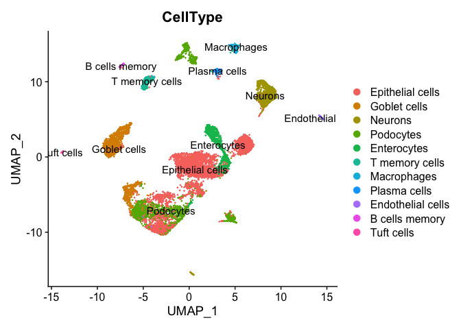

```r
DimPlot(experiment.merged, group.by = "CellType", label = TRUE)
```

## Get the next Rmd file

```r
download.file("https://raw.githubusercontent.com/msettles/2022-Uganda-Single-Cell-RNA-Seq-Analysis/main/data_analysis/scRNA_Workshop-PART7.Rmd", "scRNA_Workshop-PART7.Rmd")
```